# Chapter 1: open data and perform descriptive analysis

We start by loading the data. Recall that we created `listings_clean` and `listings_clean_accommodates_2`. The former selects observations with finite prices and review scores, more than 10 received reviews, and a price below 300 USD; the latter selects listings that accommodate 2 people.

```r
# Load data
# Load the datasets from the RData file
load("../dataCreated/listings_clean.RData")

# Display the first few rows of the cleaned dataset
head(listings_clean)
```

| id | listing_url | scrape_id | last_scraped | source | name | description | neighborhood_overview | picture_url | host_id | host_url | host_name | host_since | host_location | host_about | host_response_time | host_response_rate | host_acceptance_rate | host_is_superhost | host_thumbnail_url | host_picture_url | host_neighbourhood | host_listings_count | host_total_listings_count | host_verifications | host_has_profile_pic | host_identity_verified | neighbourhood | neighbourhood_cleansed | neighbourhood_group_cleansed | … |
| --- | --- | --- | --- | --- | --- | --- | --- | --- | --- | --- | --- | --- | --- | --- | --- | --- | --- | --- | --- | --- | --- | --- | --- | --- | --- | --- | --- | --- | --- | --- |
| 73155 | https://www.airbnb.com/rooms/73155 | 2.024063e+13 | 2024-06-25 | city scrape | Apartment in centre of Rotterdam | This bright comfortable one bedroom apartment with a architectural thouch has a true cosy feeling! It comfortably fits two and is centrally located on a quiet street, near everything you need! Shops, … | The apartment is in a quiet side street of the Witte de With. So you are near the restaurants, bars and pubs but you don't have the noise! | https://a0.muscache.com/pictures/miso/Hosting-73155/original/de9253d1-f8c9-4d29-8ef4-2b17680086ab.jpeg | 381163 | https://www.airbnb.com/users/show/381163 | Kim | 2011-02-07 | Rotterdam, Netherlands | Hi I'm Kim and I'm an architect. \r\nI studied at the TU in Delft. The apartment is renewed by myself. I wanted to created a place where you feel at home. It is a combined style of wood some color and… | within an hour | 100% | 82% | FALSE | https://a0.muscache.com/im/pictures/user/User-381163/original/7cddb6dc-4731-43ec-9b5a-9055818b02da.jpeg?aki_policy=profile_small | https://a0.muscache.com/im/pictures/user/User-381163/original/7cddb6dc-4731-43ec-9b5a-9055818b02da.jpeg?aki_policy=profile_x_medium | NA | 1 | 1 | ['email', 'phone'] | TRUE | TRUE | Rotterdam, South Holland, Netherlands | Stadsdriehoek | Rotterdam Centrum | … |
| 77592 | https://www.airbnb.com/rooms/77592 | 2.024063e+13 | 2024-06-25 | city scrape | Charming, Cozy Rotterdam Center | NA | NA | https://a0.muscache.com/pictures/e96512a1-b4c7-463e-bd52-3c99ed5f8e19.jpg | 416305 | https://www.airbnb.com/users/show/416305 | Jos | 2011-03-01 | Rotterdam, Netherlands | Welcome to Rotterdam! This apartment belongs with Hotel van Walsum, a family-run hotel in a historic building from 1895. We know you will enjoy your stay here. | within a few hours | 100% | 0% | FALSE | https://a0.muscache.com/im/pictures/user/b6041d69-c701-4b57-acbf-130741440899.jpg?aki_policy=profile_small | https://a0.muscache.com/im/pictures/user/b6041d69-c701-4b57-acbf-130741440899.jpg?aki_policy=profile_x_medium | NA | 1 | 2 | ['email', 'phone'] | TRUE | TRUE | NA | Middelland | Delfshaven | … |
| 101526 | https://www.airbnb.com/rooms/101526 | 2.024063e+13 | 2024-06-25 | city scrape | Apartment Dependance Rotterdam | NA | Lively young neighborhood. Bistro on the corner, Lots of nice shops, Museums within walking distance, Cinema, public transport all nearby. | https://a0.muscache.com/pictures/679013/0bb0d33d_original.jpg | 531869 | https://www.airbnb.com/users/show/531869 | Loes | 2011-04-24 | Rotterdam, Netherlands | I am a mimeplayer as a professional, play theatre acts on festivals, busines parties, weddings, conferences, etc. On the picture is shown me and my husband as "Henk en Ien", our cotton candy act. www.… | within an hour | 100% | 100% | FALSE | https://a0.muscache.com/im/pictures/user/eb0aa9f1-5fbd-4bd7-ae91-bfb3786fffec.jpg?aki_policy=profile_small | https://a0.muscache.com/im/pictures/user/eb0aa9f1-5fbd-4bd7-ae91-bfb3786fffec.jpg?aki_policy=profile_x_medium | NA | 1 | 1 | ['email', 'phone', 'work_email'] | TRUE | TRUE | Rotterdam, South Holland, Netherlands | Dijkzigt | Rotterdam Centrum | … |
| 539905 | https://www.airbnb.com/rooms/539905 | 2.024063e+13 | 2024-06-25 | city scrape | Sunny garden apt in Kralingen/R'dam | NA | NA | https://a0.muscache.com/pictures/6557859/860ad071_original.jpg | 2652971 | https://www.airbnb.com/users/show/2652971 | Michael | 2012-06-16 | New York, NY | This apartment is my "pied a terre" in Rotterdam acquired many years ago. Kralingen, where the apartment is located, was a village until 1895(?) and still feels like a village even though it is only 1… | N/A | N/A | N/A | FALSE | https://a0.muscache.com/im/users/2652971/profile_pic/1339865622/original.jpg?aki_policy=profile_small | https://a0.muscache.com/im/users/2652971/profile_pic/1339865622/original.jpg?aki_policy=profile_x_medium | NA | 1 | 1 | ['email', 'phone'] | TRUE | TRUE | NA | Kralingen Oost | Kralingen-Crooswijk | … |
| 763422 | https://www.airbnb.com/rooms/763422 | 2.024063e+13 | 2024-06-25 | city scrape | City appartment: b&b Walenburg | A lovely, comfortable stay in the city centre of Rotterdam. The appartment is very spacious, has it's own kitchen and a nice garden-view. At night it is very quiet. The Central Station, as well as the… | The northern side of Rotterdam Centre is an up-coming area. Here you will find authentic old pre-war houses. The atmosphere is pleasant. There are lots of nice little restaurants. | https://a0.muscache.com/pictures/51971409/2309608f_original.jpg | 4024319 | https://www.airbnb.com/users/show/4024319 | Machteld | 2012-10-31 | Rotterdam, Netherlands | I'm an event organiser in creative industry, based in Rotterdam, the Netherlands. I live in the city center of Rotterdam for almost 25 years and I can tell you: I love my city. I also like to travel, … | within an hour | 100% | 100% | TRUE | https://a0.muscache.com/im/users/4024319/profile_pic/1351757885/original.jpg?aki_policy=profile_small | https://a0.muscache.com/im/users/4024319/profile_pic/1351757885/original.jpg?aki_policy=profile_x_medium | NA | 2 | 3 | ['email', 'phone'] | TRUE | TRUE | Rotterdam, South Holland, Netherlands | Blijdorp | Noord | … |
| 1322782 | https://www.airbnb.com/rooms/1322782 | 2.024063e+13 | 2024-06-25 | city scrape | Spacious room close to city centre | NA | NA | https://a0.muscache.com/pictures/66768021/f135743b_original.jpg | 6926282 | https://www.airbnb.com/users/show/6926282 | Marion | 2013-06-15 | Rotterdam, Netherlands | NA | within a day | 70% | 33% | FALSE | https://a0.muscache.com/im/pictures/user/5142c904-7e23-4a97-9984-3249cf8bd443.jpg?aki_policy=profile_small | https://a0.muscache.com/im/pictures/user/5142c904-7e23-4a97-9984-3249cf8bd443.jpg?aki_policy=profile_x_medium | NA | 3 | 4 | ['email', 'phone'] | TRUE | TRUE | NA | Nieuwe Westen | Delfshaven | … |

Create some summary statistics.

```r
# Create a summary statistics table with one row per variable
summary_stats <- tibble::tibble(
  Variable = c("Price", "Review Scores Rating", "Accommodates"),
  Mean = c(round(mean(listings_clean$price, na.rm = TRUE), 2),
           round(mean(listings_clean$review_scores_rating, na.rm = TRUE), 2),
           round(mean(listings_clean$accommodates, na.rm = TRUE), 2)),
  Median = c(round(median(listings_clean$price, na.rm = TRUE), 2),
             round(median(listings_clean$review_scores_rating, na.rm = TRUE), 2),
             round(median(listings_clean$accommodates, na.rm = TRUE), 2)),
  Standard_Deviation = c(round(sd(listings_clean$price, na.rm = TRUE), 2),
                         round(sd(listings_clean$review_scores_rating, na.rm = TRUE), 2),
                         round(sd(listings_clean$accommodates, na.rm = TRUE), 2)),
  Min = c(round(min(listings_clean$price, na.rm = TRUE), 2),
          round(min(listings_clean$review_scores_rating, na.rm = TRUE), 2),
          round(min(listings_clean$accommodates, na.rm = TRUE), 2)),
  Max = c(round(max(listings_clean$price, na.rm = TRUE), 2),
          round(max(listings_clean$review_scores_rating, na.rm = TRUE), 2),
          round(max(listings_clean$accommodates, na.rm = TRUE), 2))
)

# Display the summary statistics table
summary_stats
```

| Variable | Mean | Median | Standard_Deviation | Min | Max |
| --- | --- | --- | --- | --- | --- |
| Price | 130.08 | 123.0 | 59.02 | 28.00 | 293 |
| Review Scores Rating | 4.75 | 4.8 | 0.21 | 3.99 | 5 |
| Accommodates | 3.03 | 2.0 | 1.87 | 1.00 | 16 |

Histogram of `price` for those apartments accommodating 2 people.

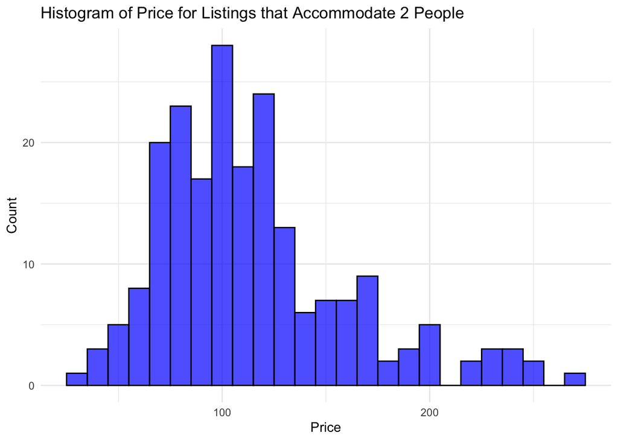

```r
# Create the histogram
ggplot(listings_clean_accommodates_2, aes(x = price)) +
  geom_histogram(binwidth = 10, fill = "blue", color = "black", alpha = 0.7) +
  labs(
    title = "Histogram of Price for Listings that Accommodate 2 People",
    x = "Price",
    y = "Count"
  ) +
  theme_minimal()
```

What is the empirical relationship between the price and the review score for an apartment that accommodates 2 people? One can look at a scatter plot.

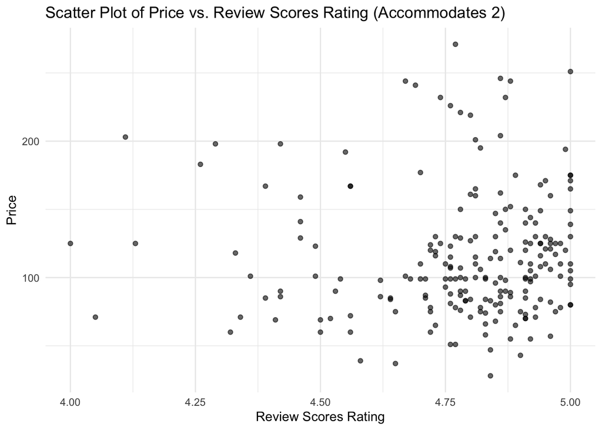

```r
# Create the scatter plot
ggplot(listings_clean_accommodates_2, aes(x = review_scores_rating, y = price)) +
  geom_point(alpha = 0.6) +
  labs(
    title = "Scatter Plot of Price vs. Review Scores Rating (Accommodates 2)",
    x = "Review Scores Rating",
    y = "Price"
  ) +
  theme_minimal()
```

Or at a correlation.

```r
# Calculate the correlation between price and review_scores_rating
correlation <- cor(listings_clean_accommodates_2$price, listings_clean_accommodates_2$review_scores_rating, use = "complete.obs")

# Display the correlation
correlation
```

```
## [1] 0.009672447
```

How does the price for an apartment that accommodates 2 vary by neighborhood?

```r
# Create a summary table with the average price for each neighborhood
neighborhood_price_summary <- listings_clean_accommodates_2 %>%
  group_by(neighbourhood) %>%
  summarise(average_price = round(mean(price, na.rm = TRUE), 2)) %>%
  arrange(neighbourhood)

# Display the summary table
neighborhood_price_summary
```

| neighbourhood | average_price |
| --- | --- |
| Rotterdam, Netherlands | 121.00 |
| Rotterdam, So, Netherlands | 110.00 |
| Rotterdam, South Holland, Netherlands | 96.44 |
| Rotterdam, ZH, Netherlands | 94.22 |
| Rotterdam, Zu, Netherlands | 115.00 |
| Rotterdam, Zuid-Holland, Netherlands | 116.55 |
| NA | 118.47 |

How does the price vary with the number of people that can stay in an apartment. We wille explore this using a set of so-called box plots.

A box plot, or box-and-whisker plot, visually displays the distribution of data using five key metrics: the minimum, first quartile (Q1), median (Q2), third quartile (Q3), and maximum. The box shows the interquartile range (IQR), representing the middle 50% of the data, with the line inside the box indicating the median. Whiskers extend from the box to the smallest and largest values within 1.5 times the IQR. Outliers, or points outside this range, are shown as individual dots. Box plots are useful for quickly assessing the spread, center, and potential outliers in the data.

We make a figure with one box plot for each value of `accommodates`.

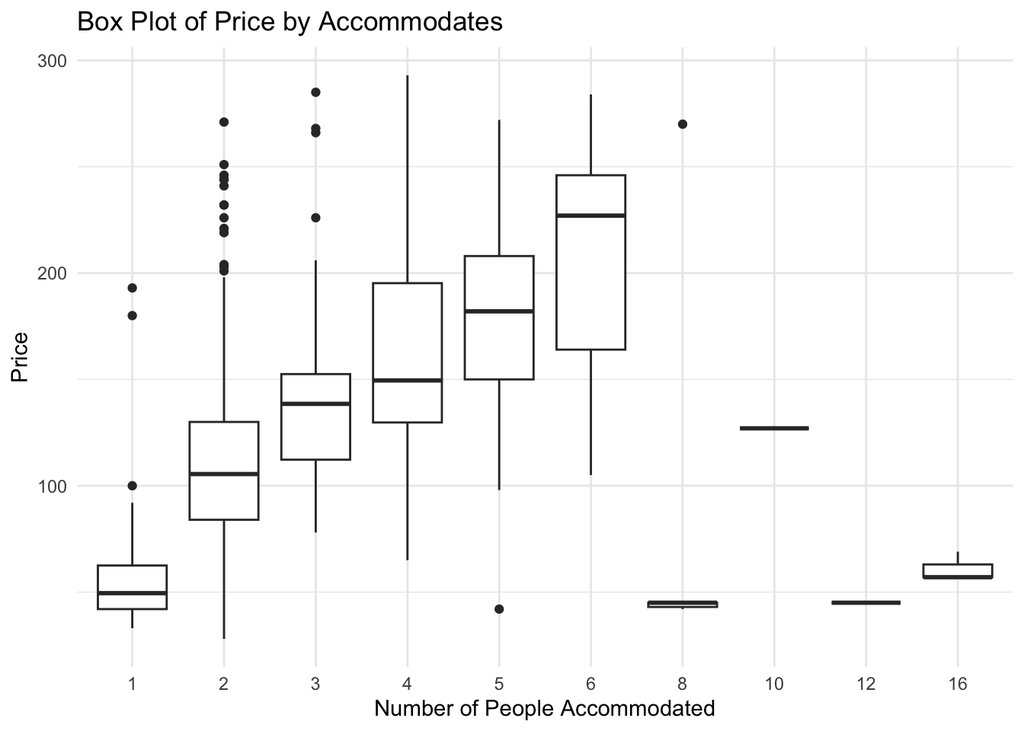

```r
# Create box plots of price by accommodates
ggplot(listings_clean, aes(x = factor(accommodates), y = price)) +
  geom_boxplot() +
  labs(
    title = "Box Plot of Price by Accommodates",
    x = "Number of People Accommodated",
    y = "Price"
  ) +
  theme_minimal()
```